# Introduction to R

## Other dplyr verbs

1. `filter` - dplyr’s version of `subset`
2. `mutate` - more easily add variables to a dataframe
3. `sample` - randomly sample rows from dataframe
4. `%>%` - pipe operator. Chain together commands as opposed to nesting commands

Many, many more.

## Reading in Outside Data

Up to now, we have been concerned with user-generated data from inside R, however most data will need to be imported instead. Luckily there are a variety of functions and packages for importing all kinds of data.

1. `utils`: import using base R. `read.table, read.csv, read.delim, etc.`
2. `readr`: specialized for rectangular text data. `read_table, read_csv, read_delim`
3. `foreign`: import from other data processing programs. `read.spss, read.octave, etc.`
4. `readxl`: import excel tables. `read_xls, read_xlsx, read_excel`

Let’s look at an example comma-separated value (csv) text file and how to import that into R.

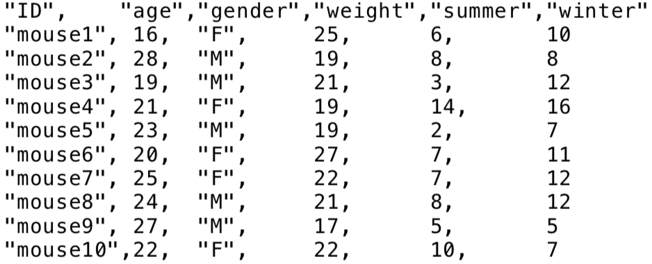

**NOTE:** The commas in this file are called the delimiter. Any single symbol can be used as a delimiter, however the most common are commas, tabs, and spaces.

```r
mouse.df.read <- read.delim("~/Desktop/mousedf.csv", sep = ",")

mouse.df.read
```

```
##         ID age gender weight summer winter
## 1   mouse1  16      F     25      6     10
## 2   mouse2  28      M     19      8      8
## 3   mouse3  19      M     21      3     12
## 4   mouse4  21      F     19     14     16
## 5   mouse5  23      M     19      2      7
## 6   mouse6  20      F     27      7     11
## 7   mouse7  25      F     22      7     12
## 8   mouse8  24      M     21      8     12
## 9   mouse9  27      M     17      5      5
## 10 mouse10  22      F     22     10      7
```

`read.csv` is a shortcut for `read.delim` where the delimiter is assumed to be a comma, so it is more apt for this situation

```r
mouse.df.read <- read.csv("~/Desktop/mousedf.csv")

mouse.df.read
```

```
##         ID age gender weight summer winter
## 1   mouse1  16      F     25      6     10
## 2   mouse2  28      M     19      8      8
## 3   mouse3  19      M     21      3     12
## 4   mouse4  21      F     19     14     16
## 5   mouse5  23      M     19      2      7
## 6   mouse6  20      F     27      7     11
## 7   mouse7  25      F     22      7     12
## 8   mouse8  24      M     21      8     12
## 9   mouse9  27      M     17      5      5
## 10 mouse10  22      F     22     10      7
```

Sometimes, data may be stored in excel sheets. R can import those with ease as well using the `readxl` package. Use `read_xls` or `read_xlsx` if you know the file type, otherwise use `read_excel` and it will guess which is more appropriate. So our data in excel would look like this:

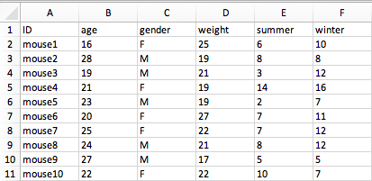

Since we know our file type (xlsx here), we will use `read_xlsx`

```r
mouse.df.read <- read_xlsx(path = "~/Desktop/mousedf.xlsx")

mouse.df.read
```

```
## # A tibble: 10 x 6
##    ID        age gender weight summer winter
##    <chr>   <dbl> <chr>   <dbl>  <dbl>  <dbl>
##  1 mouse1     16 F          25      6     10
##  2 mouse2     28 M          19      8      8
##  3 mouse3     19 M          21      3     12
##  4 mouse4     21 F          19     14     16
##  5 mouse5     23 M          19      2      7
##  6 mouse6     20 F          27      7     11
##  7 mouse7     25 F          22      7     12
##  8 mouse8     24 M          21      8     12
##  9 mouse9     27 M          17      5      5
## 10 mouse10    22 F          22     10      7
```

After importing data, be sure to check the variable types for the data frame like we did before (`str` function). Import functions have trouble determining between characters, factors and others, so make sure you’re data is the way you want it before working with it.

## Questions?

## Graphing with ggplot

Lastly, `ggplot` is the plotting tool of choice for most things in R. The gg in the name stands for the **grammar of graphics**, the high-level idea you can build any graph from the same components:

1. Data
2. A coordinate system
3. Visual marks that represent data points

At a low-level, every ggplot function call has 3 properties to it:

1. Data
2. Aesthetic mappings between the data and visual properties of the graph (x, y, color, etc.)
3. Geoms - layers that render the data

Aesthetics are controlled via the `aes` function. This function maps properties of the graph to variables in the data frame.

A simple example would be plotting the weight of a mouse versus its age in a scatter plot.

**NOTE: I have added data to the dataframe, specifically 10 more mice. This will make the plots more populated.**

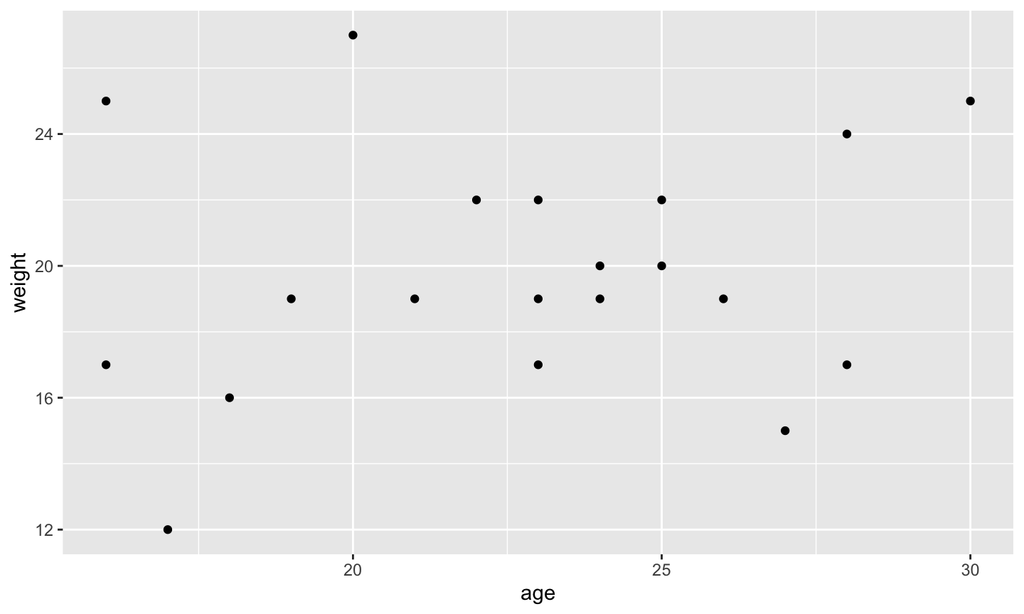

```r
ggplot(data = mouse.df, mapping = aes(x = age, y = weight)) +
  geom_point()
```

This produces a scatterplot defined by:

1. Data: mouse.df
2. Aesthetics: age mapped to the x axis, weight mapped to the y axis
3. Layer: points

The basic structure is that data and aesthetics are supplied in the `ggplot` call and the layers are added on with `+`

x and y are not the only aesthetics you’ll want to use when plotting. `aes` gives access to many different properties of the geoms such as

- color
- size
- shape
- fill
- transparency (alpha)
- and more!

For instance, if we wanted to differentiate males and females by color, it would look like:

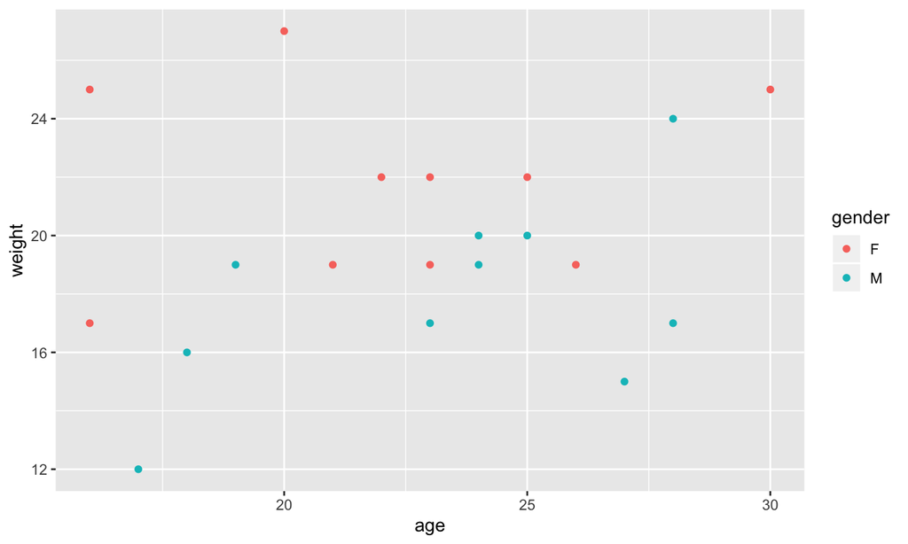

```r
#Plot different genders as different colors
ggplot(mouse.df, aes(age, weight, color = gender)) +
  geom_point()
```

In the previous graph, those points may have been difficult to see. This problem raises the question of how to change properties of the graph without mapping to a variable. Luckily, you can manually set a value for any of the previous properties in the geom call. For example:

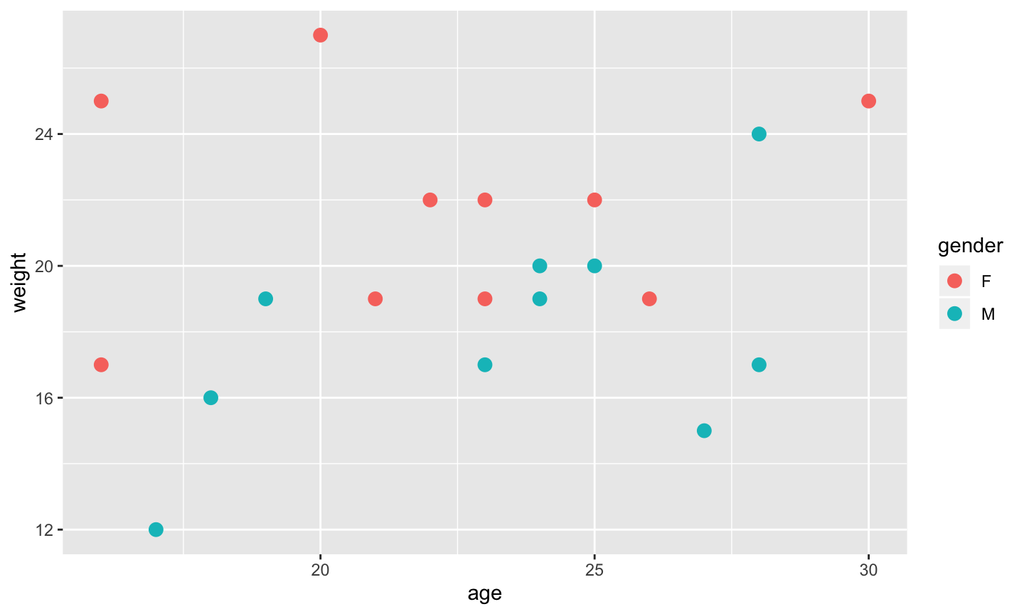

```r
#Plot different genders as different colors
ggplot(mouse.df, aes(age, weight, color = gender)) +
  geom_point(size = 3)
```

In this relatively simple dataset, it’s easy to see differences between the groups on that plot. However with much larger datasets, visual differences can be muddled if all the groups are plotted on the same graph. Faceting helps with this. Faceting splits data by a specification variable in the facet command. The generally most useful facet command is

`facet_wrap(~var)`

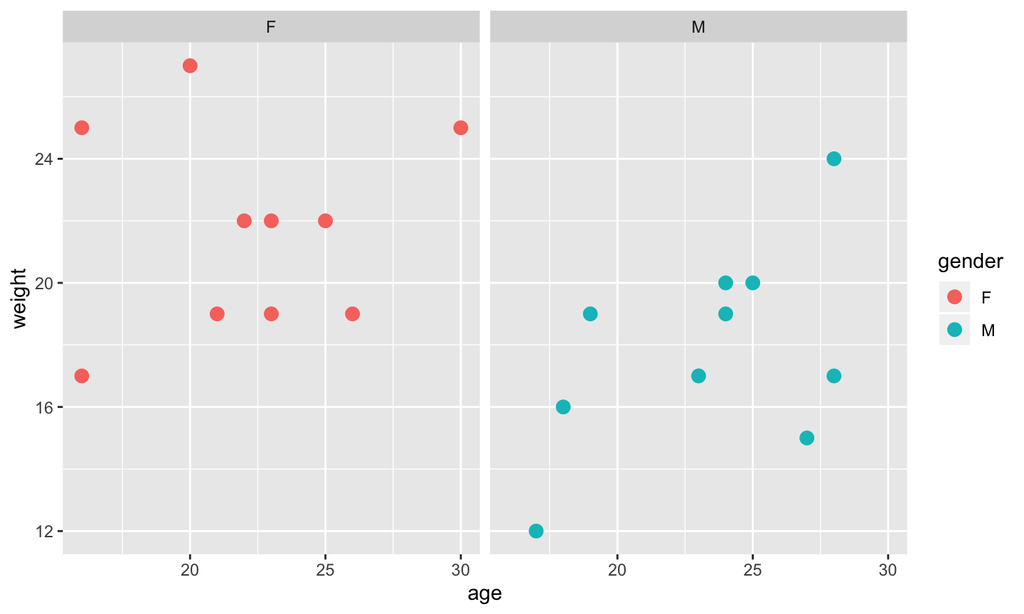

```r
#Plot different genders in different facet plots
ggplot(mouse.df, aes(age, weight, color = gender)) +
  geom_point(size = 3) +
  facet_wrap(~gender)
```

## Multiple Geoms

Up until now, we have worked with one geom at a time to represent our data. However, plotting multiple geoms is common. Multiple geoms can be added easily with extra geom functions. For example, if we wanted to plot a dot and line plot using the age and weight data.

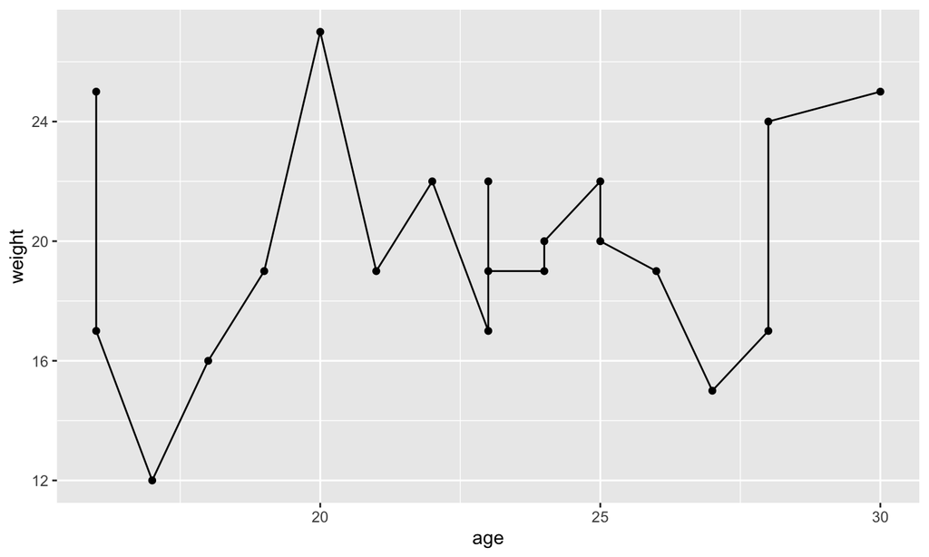

```r
ggplot(mouse.df,aes(age,weight)) +
  geom_point() +
  geom_line()
```

However, what if we wanted to differentiate dots by color again? We can add back in that aesthetic to the ggplot call, but it has an unintended consequence on the line plot:

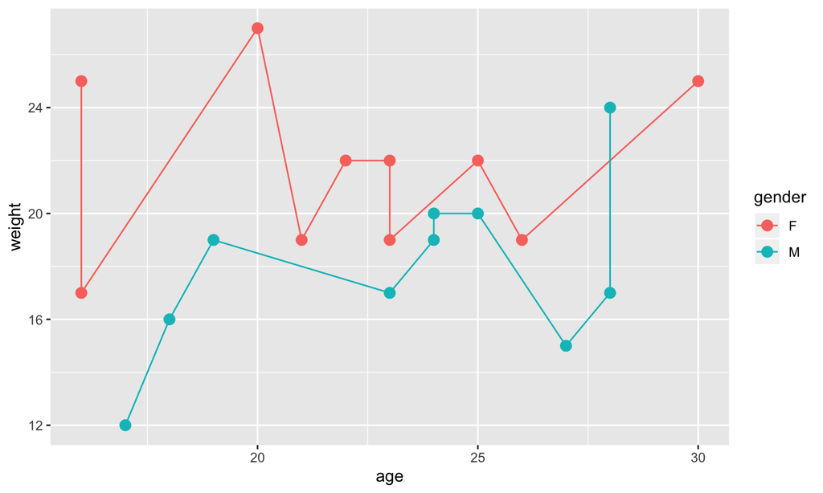

```r
ggplot(mouse.df,aes(age,weight, color = gender)) +
  geom_point(size = 3) +
  geom_line()
```

## Inhereted Aesthetics

In the previous plot, we only wanted the dots to change color, but the line to stay the same, so why did the line geom split by gender as well?

In ggplot, all aesthetics named in the `ggplot` call are passed down to every following geom function. So both `geom_point` and `geom_line` have the same aesthetics of:

1. `x = age`
2. `y = weight`
3. `color = gender`

We say that the geoms **inherit** the aesthetics of the original ggplot call

Inhereted aesthetics are an extremely important concept in ggplot. It means you do not have to tell each individual geom call what’s x, y, and whatever else making code much cleaner overall.

However, inhereted aesthetics become slightly problematic if you want one geom to apply to subgroups (plotting dots as different colors by gender) and another geom to apply to the data as a whole (connect all points with a single line)

Luckily, ggplot also makes this fairly easy as you can name aesthetics inside the geom calls themselves, and those aesthetics will be local only to that geom.

For example, let’s again try to plot the dots as different colors, but plot a single line plot for the whole group:

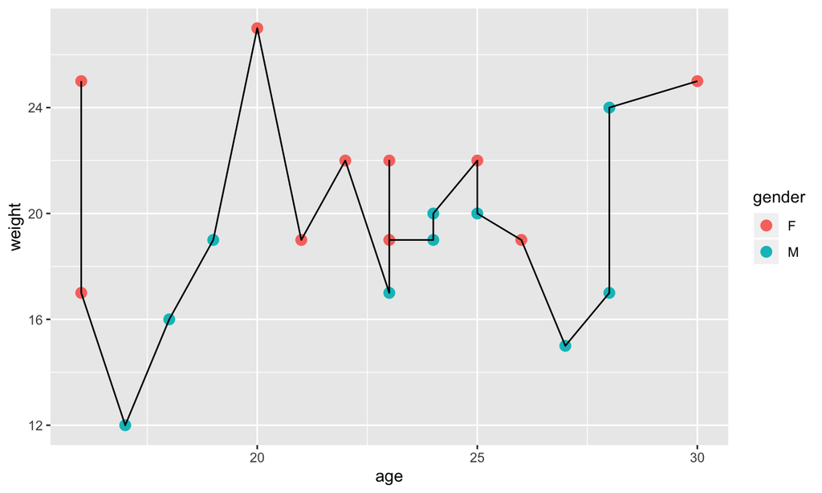

```r
ggplot(mouse.df,aes(age,weight)) +
  geom_point(aes(color = gender), size = 3) +
  geom_line()
```

Constantly keep in mind how you want your graph to look at the end and which aesthetics are appropriate for which geoms.

Drawing your sketches of your graph on paper will help organize which geoms and aesthetics are appropriate and will save time overall.

## Questions?

## Plotting Discrete Vs. Continuous Values

So far, we have only been concerned with continuous values on the x and y axes. However, plotting discrete values instead is just as easy as continuous.

Let’s plot a boxplot of male vs. female average summer sleep time

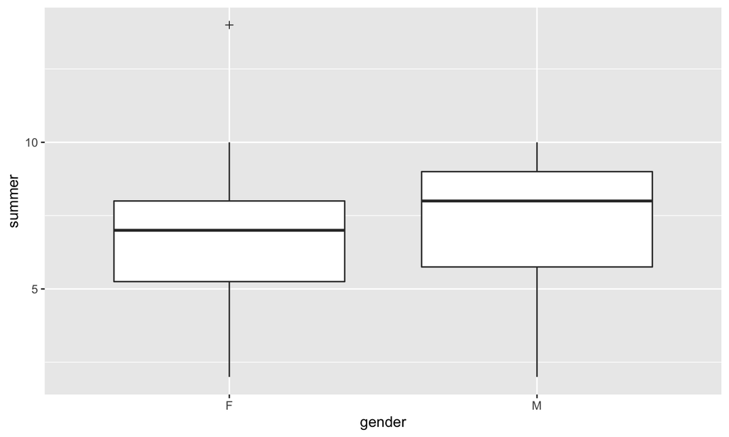

```r
ggplot(mouse.df,aes(gender,summer)) +
  geom_boxplot(outlier.shape = 3)
```

We can also easily add points to the plot as well overlayed on top of the boxplot

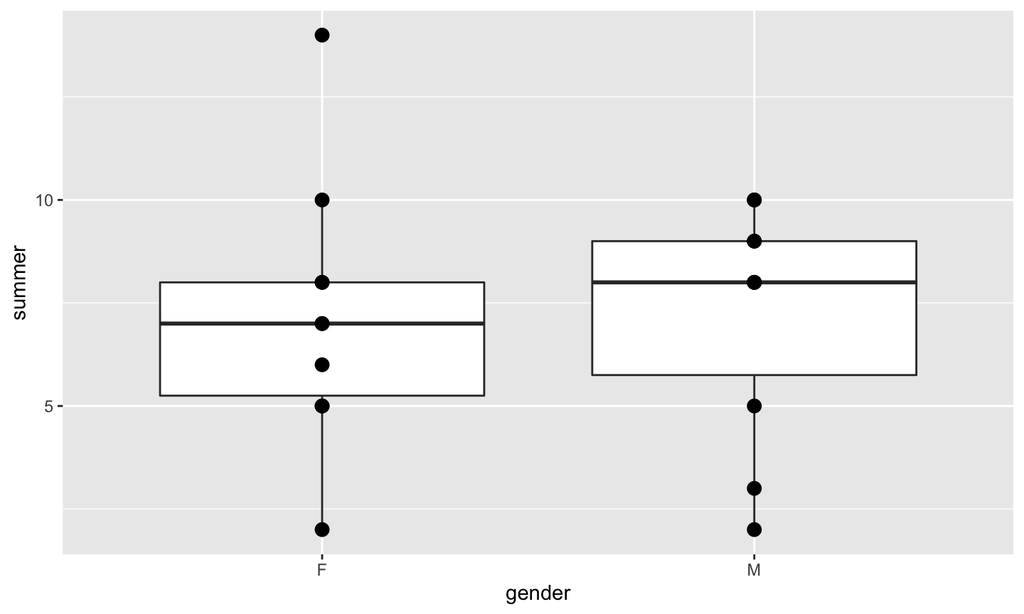

```r
ggplot(mouse.df,aes(gender,summer)) +
  geom_boxplot(outlier.shape = 3) +
  geom_point(size = 3)
```

You may notice that the number of points on the graph does not match the number of points we know we have for each group. This is because some mice sleep the same amount of time, so their points are plotted over each other. We can offset x positions using `geom_jitter` as opposed to `geom_point` so that all dots can be seen on the graph.

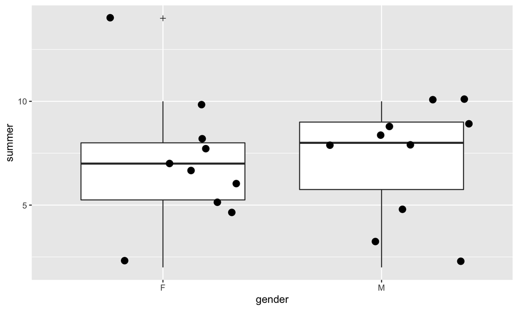

```r
ggplot(mouse.df,aes(gender,summer)) +
  geom_boxplot(outlier.shape = 3) +
  geom_jitter(size = 3)
```

We can change the width of the jitter using the `width` variable in the `geom_jitter` call

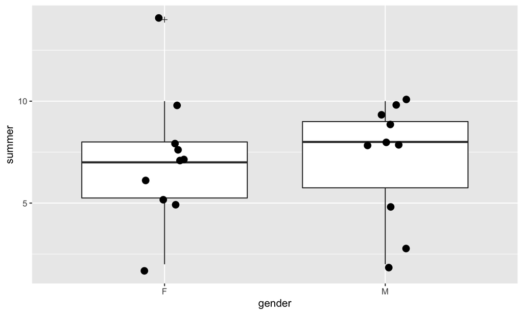

```r
ggplot(mouse.df,aes(gender,summer)) +
  geom_boxplot(outlier.shape = 3) +
  geom_jitter(size = 3, width = 0.1)
```

## Tidy Data and ggplot

Given how aesthetics are named, ggplot works best with tidy data. For example, given how our current data frame is set up, plotting average sleep time for summer vs winter would be very difficult. However, if we gather the data like we did earlier, it makes plotting much easier

```r
mouse.df.g <- gather(mouse.df, key = "season", value = "avg.sleep", summer,winter)
head(mouse.df.g)
```

```
##       ID age gender weight season avg.sleep
## 1 mouse1  16      F     25 summer         6
## 2 mouse2  28      M     17 summer         8
## 3 mouse3  19      M     19 summer         3
## 4 mouse4  21      F     19 summer        14
## 5 mouse5  23      M     17 summer         2
## 6 mouse6  20      F     27 summer         7
```

Now, we can make a bar plot of avg.sleep time vs. season.

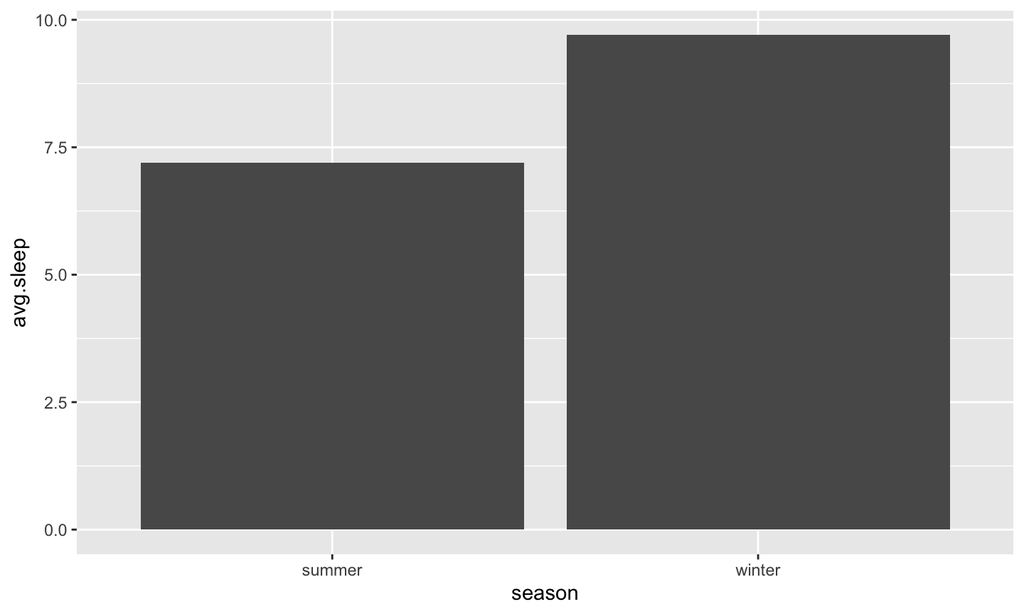

```r
ggplot(mouse.df.g, aes(season,avg.sleep)) +
  geom_bar(stat = "summary", fun.y = "mean")
```

However, what if we wanted to see if there are also differences between males and females as well as between seasons? We can add a fill aesthetic for this.

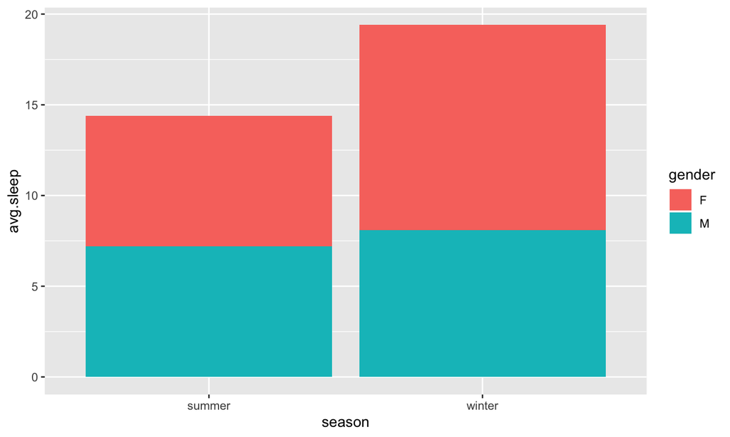

```r
ggplot(mouse.df.g, aes(season,avg.sleep, fill = gender)) +
  geom_bar(stat = "summary", fun.y = "mean")
```

`geom_bar` by default stacks results on top of one another. We can get around this using the `position = position_dodge()` option in `geom_bar`

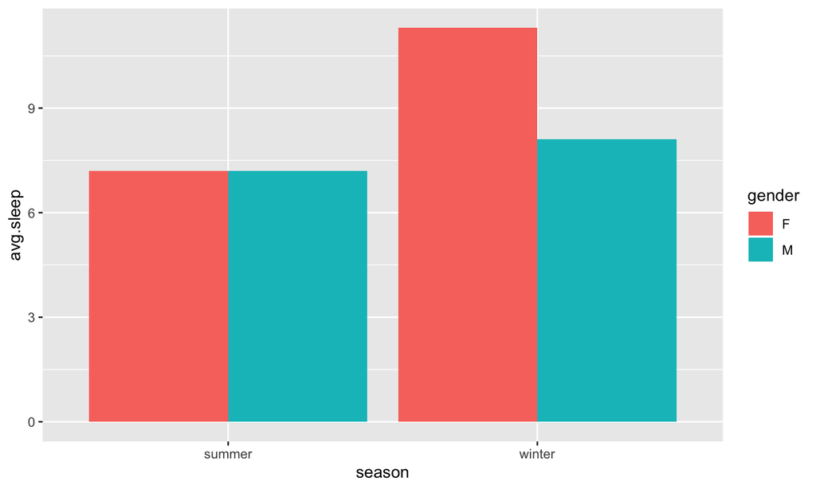

```r
ggplot(mouse.df.g, aes(season,avg.sleep, fill = gender)) +
  geom_bar(stat = "summary", fun.y = "mean", position = position_dodge())
```

## Storing Plots as Variables

`ggplot` objects can be stored as variables to make trying out different layers easier with less typing. For example, we can store the bar plot we just made in a variable `bar`

```r
bar <- ggplot(mouse.df.g, aes(season, avg.sleep, fill = gender)) +
  geom_bar(stat = "summary", fun.y = "mean", position = position_dodge())
```

We can then just call `bar` to again plot the graph stored

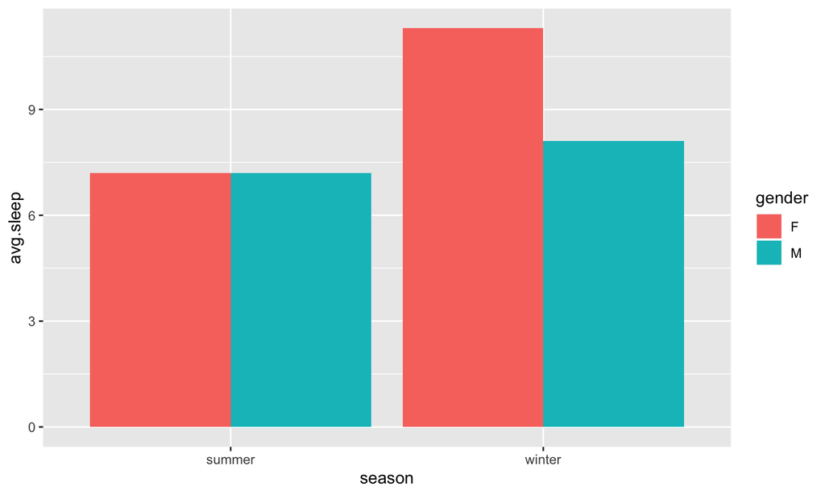

```r
bar
```

You can also add layers using `+`. So if we wanted to add points to the plot, we can call

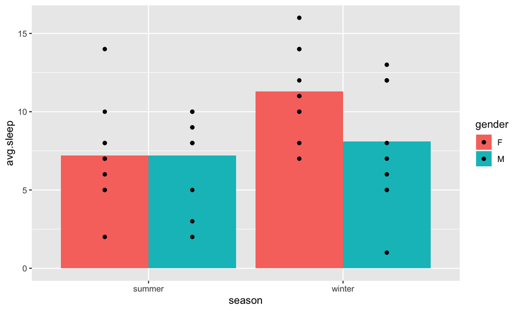

```r
bar + geom_point(position = position_dodge(width = 0.9))
```

## Errorbars

Errorbars are essential for publication quality plots. We can use the `stat_summary` function to create errorbars representing the standard error of the mean for us for each group.

For this case, the `stat_summary` function works by giving it 2 important variables:

1. fun.data: the function to apply to the data. Various functions exist for this such as `mean_se`, `mean_sdl`, `mean_cl_boot`, and others
2. geom: the geom used to represent the errorbars. Can be one of 4 different types: `errorbar`, `pointrange`, `linerange`, or `crossbar`

For example, if we wanted to add errorbars to the previous plot:

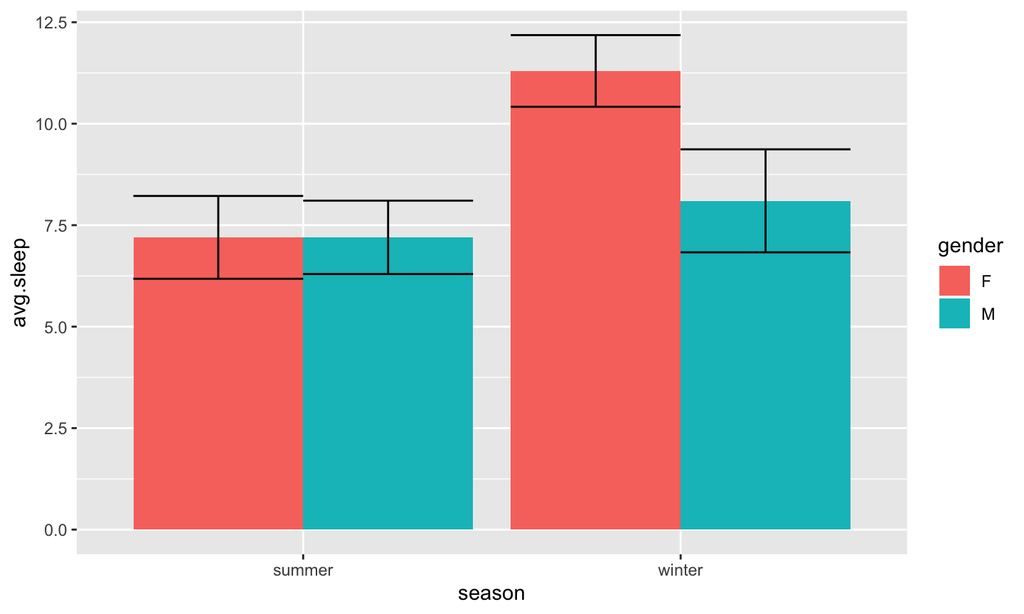

```r
bar + stat_summary(fun.data = mean_se, geom = "errorbar",
                   position = position_dodge())
```

By default, the width of the errorbars are the width of the bars. We can change this using the `width` option in `stat_summary`, but this also changes the errorbars’ horizontal offset

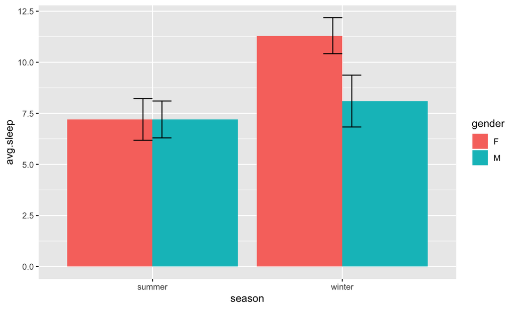

```r
bar + stat_summary(fun.data = mean_se, geom = "errorbar",
                   position = position_dodge(), width = 0.2)
```

To fix this, we will manually set the `position_dodge` argument to be 0.9, the default offset. For more complex graphs, you may need to play around with this number to place errorbars exacly where you want them

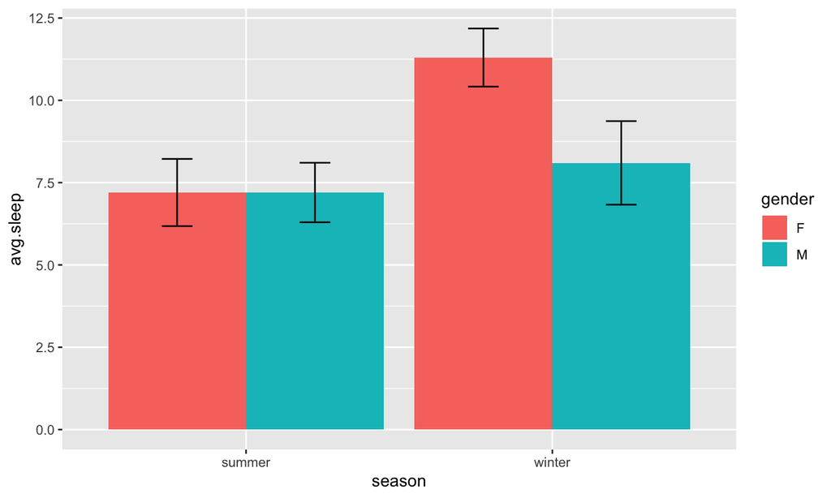

```r
bar + stat_summary(fun.data = mean_se, geom = "errorbar",
                   position = position_dodge(0.9), width = 0.2)
```

## Themes, axes, and titles

`ggplot` claims to be able to make publication quality plots out of the box, however the defaults may not be suitable. The Theme of a graph refers to general aesthetics of the graph itself such as the font type and size, the background color, the presence of gridlines, etc. Titles are not added by default but can be with a simple command, and axis labels are named as the variable they represent by default but can also be changed.

### Themes

Any thematic element of the graph can changed using the `theme` command. A mojority of the little things you want to change about the graph, you will need to google, but for example, if we wanted to change the font size on the axes, we could use a command like this:

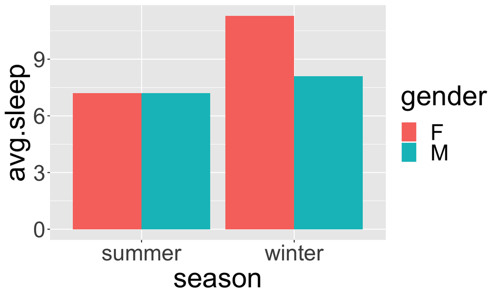

```r
bar + theme(text = element_text(size = 30))
```

There are a ton of different options to change that cannot be summarized well here, but google is your best friend.

There are some stock themes included in ggplot that can be used as one-liners to change many things about a plot at once. These themes are listed and can be seen at this link: [ggplot themes](https://ggplot2.tidyverse.org/reference/ggtheme.html)

### Titles and Axis Labels

Titles and axis labels can be added easily using the `xlab`, `ylab`, and `ggtitle` commands. These have the basic form:

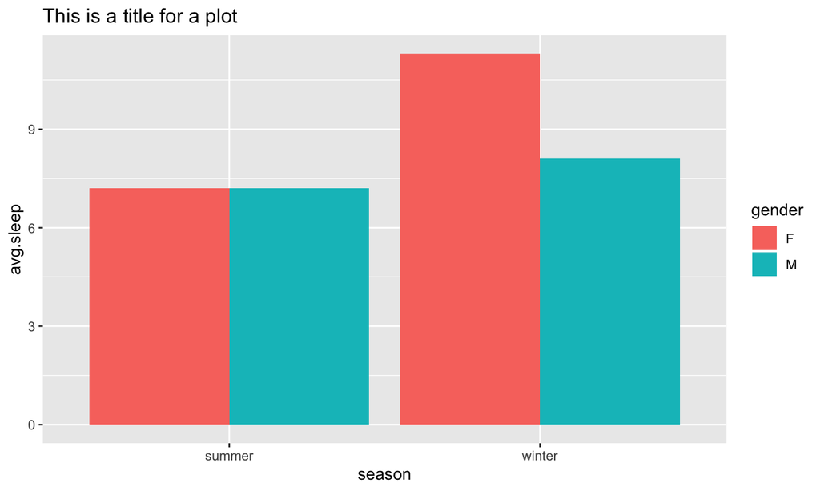

```r
bar + ggtitle("This is a title for a plot")
```

Obviously, you will need to center the text and change the font size for it using the `theme` command, but that is the general way of adding titles and axis labels to the plot.

## Helpful Outside Resources

1. [ggplot2: Elegant Graphics for Data Analysis](http://www.ievbras.ru/ecostat/Kiril/R/Biblio_N/R_Eng/Wickham2016.pdf)
2. [R for Data Science](https://r4ds.had.co.nz/)
3. [Learning Statistics with R](https://learningstatisticswithr.com/lsr-0.6.pdf)
4. [R Cheatsheets](https://www.rstudio.com/resources/cheatsheets/)